# Assignment 04: Tidy Data & Joins

Icíar Fernández Boyano

05/10/2019

##### Full instructions for this assignment can be found **[here](https://stat545.stat.ubc.ca/evaluation/hw04/hw04/).**

### *Set up*

```r
library(tidyverse)
```

[output not shown]

### **Exercise 1: Univariate Data Reshaping**

#### **Univariate Option 1**

##### 1. Make a tibble with one row per year, and columns for life expectancy for two or more countries.

*Notes*

- I used the package **‘gt’** to produce a nice-looking table instead of the usual knitr::kable. I used [this](https://gt.rstudio.com/articles/intro-creating-gt-tables.html), and the package is available for download [here](https://github.com/rstudio/gt).

```r
gapminder_wide <-
  gapminder %>%
  pivot_wider(id_cols = year,
              names_from = "country",
              values_from = lifeExp) %>% # At this point, we have columns for all countries showing life exp
  select(year, Spain, Canada) %>% # Selecting two countries
  gt() %>%
  tab_header(title = "Life Expectancy over time in Spain and Canada")

gapminder_wide # prints table
```

Life Expectancy over time in Spain and Canada

| year | Spain | Canada |
| --- | --- | --- |
| 1952 | 64.940 | 68.750 |
| 1957 | 66.660 | 69.960 |
| 1962 | 69.690 | 71.300 |
| 1967 | 71.440 | 72.130 |
| 1972 | 73.060 | 72.880 |
| 1977 | 74.390 | 74.210 |
| 1982 | 76.300 | 75.760 |
| 1987 | 76.900 | 76.860 |
| 1992 | 77.570 | 77.950 |
| 1997 | 78.770 | 78.610 |
| 2002 | 79.780 | 79.770 |
| 2007 | 80.941 | 80.653 |

##### 2. Take advantage of this new data shape to scatterplot life expectancy for one country against that of another.

*Notes*

- I used the package [‘wes anderson’](https://github.com/karthik/wesanderson) that has different colour palettes for each of his movies to add colour to this scatterplot.

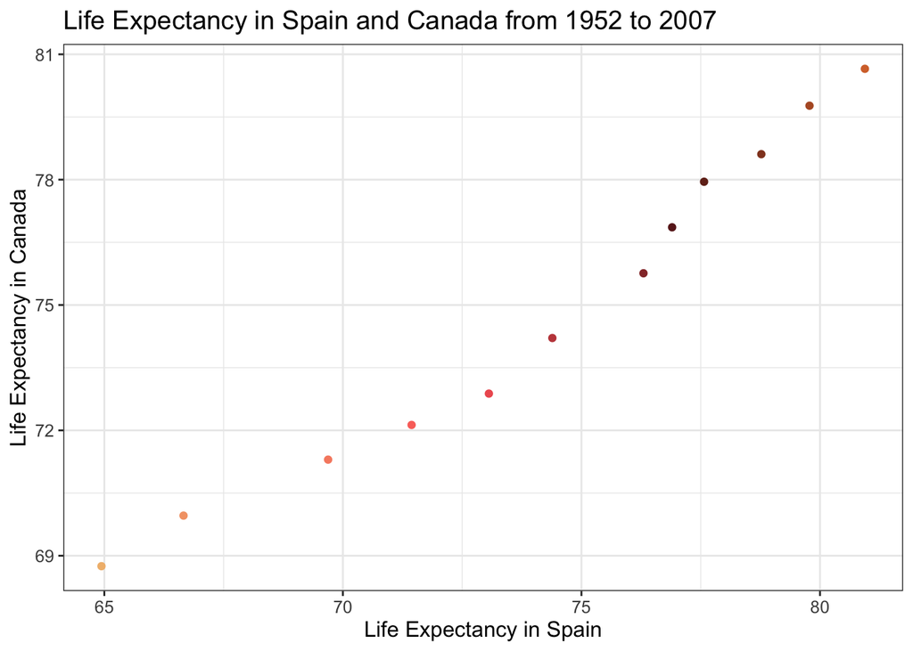

```r
LifeExp.plot <-
  gapminder_wide %>%
  ggplot(aes(Spain, Canada)) +
  geom_point(color=wes_palette("GrandBudapest1", 12, type = "continuous")) +
  ggtitle("Life Expectancy in Spain and Canada from 1952 to 2007") +
  xlab("Life Expectancy in Spain") +
  ylab("Life Expectancy in Canada") +
  theme_bw() +
  theme(text = element_text(size = 12))

LifeExp.plot # Prints plot
```

##### 3. Re-lengthen the data.

3. Re-lengthen the data.

```r
gapminder_length <-
  gapminder_wide %>%
  pivot_longer(cols = -year,
               names_to = "country",
               values_to = "lifeExp") %>%
  DT::datatable()

gapminder_length # Print
```

|  | year | country | lifeExp |
| --- | --- | --- | --- |
| 1 | 1952 | Spain | 64.94 |
| 2 | 1952 | Canada | 68.75 |
| 3 | 1957 | Spain | 66.66 |
| 4 | 1957 | Canada | 69.96 |
| 5 | 1962 | Spain | 69.69 |
| 6 | 1962 | Canada | 71.3 |
| 7 | 1967 | Spain | 71.44 |
| 8 | 1967 | Canada | 72.13 |
| 9 | 1972 | Spain | 73.06 |
| 10 | 1972 | Canada | 72.88 |

[output cut: 14 more lines]

### **Exercise 2: Multivariate Data Reshaping**

#### **Multivariate Option 1**

##### 1. Make a tibble with one row per year, and columns for life expectancy and GDP per capita (or two other numeric variables) for two or more countries.

[output not shown]

*Notes on Exercise 1*

- For 1.1, I used the package ‘gt’ to produce a nice-looking table instead of the usual knitr::kable. I used [this](https://gt.rstudio.com/articles/intro-creating-gt-tables.html), and the package is available for download [here](https://github.com/rstudio/gt).

### **Exercise 2: Multivariate Data Reshaping**

1. Make a tibble with one row per year, and columns for life expectancy and GDP per capita (or two other numeric variables) for two or more countries.

```r
# Reshaping data
gapminder_reshape <-
  gapminder %>%
  pivot_wider(id_cols  = year,
              names_from = country,
              names_sep = "_",
              values_from = c("lifeExp", "gdpPercap")) %>% # At this point, data is for all countries
  select(year, lifeExp_Spain, lifeExp_Canada, gdpPercap_Spain, gdpPercap_Canada)

# Making a nice looking table for presentation

gapminder_reshape %>%
  rename("Life.Spain" = lifeExp_Spain, "Life.Canada" = lifeExp_Canada, "GDP.Spain" = gdpPercap_Spain, "GDP.Canada" = gdpPercap_Canada) %>%
  gt() %>%
  tab_header(title = "Exploring two variables from the Gapminder dataset",
             subtitle = "From 1952 to 2007") %>%
  tab_spanner(label = "Life Expectancy",
              columns = vars(Life.Spain, Life.Canada)) %>%
  tab_spanner(label = "GDP Per Capita",
              columns = vars(GDP.Spain, GDP.Canada))
```

Exploring two variables from the Gapminder dataset

From 1952 to 2007

| year | Life Expectancy |  | GDP Per Capita |  |
| --- | --- | --- | --- | --- |
|  | Life.Spain | Life.Canada | GDP.Spain | GDP.Canada |
| 1952 | 64.940 | 68.750 | 3834.035 | 11367.16 |
| 1957 | 66.660 | 69.960 | 4564.802 | 12489.95 |
| 1962 | 69.690 | 71.300 | 5693.844 | 13462.49 |
| 1967 | 71.440 | 72.130 | 7993.512 | 16076.59 |
| 1972 | 73.060 | 72.880 | 10638.751 | 18970.57 |
| 1977 | 74.390 | 74.210 | 13236.921 | 22090.88 |
| 1982 | 76.300 | 75.760 | 13926.170 | 22898.79 |
| 1987 | 76.900 | 76.860 | 15764.983 | 26626.52 |
| 1992 | 77.570 | 77.950 | 18603.065 | 26342.88 |
| 1997 | 78.770 | 78.610 | 20445.299 | 28954.93 |
| 2002 | 79.780 | 79.770 | 24835.472 | 33328.97 |
| 2007 | 80.941 | 80.653 | 28821.064 | 36319.24 |

##### 2. Re-lengthen the data.

2. Re-lengthen the data.

```r
gapminder_reshape %>%
  pivot_longer(cols = -year,
               names_to = c(".value", "country"),
               names_sep = "_") %>%
  DT::datatable()
```

|  | year | country | lifeExp | gdpPercap |
| --- | --- | --- | --- | --- |
| 1 | 1952 | Spain | 64.94 | 3834.034742 |
| 2 | 1952 | Canada | 68.75 | 11367.16112 |
| 3 | 1957 | Spain | 66.66 | 4564.80241 |
| 4 | 1957 | Canada | 69.96 | 12489.95006 |
| 5 | 1962 | Spain | 69.69 | 5693.843879 |
| 6 | 1962 | Canada | 71.3 | 13462.48555 |
| 7 | 1967 | Spain | 71.44 | 7993.512294 |
| 8 | 1967 | Canada | 72.13 | 16076.58803 |
| 9 | 1972 | Spain | 73.06 | 10638.75131 |
| 10 | 1972 | Canada | 72.88 | 18970.57086 |

[output cut: 14 more lines]

[output not shown]

### **Exercise 3: Table Joins**

##### **3.1: For each guest in the guestlist (guest tibble), add a column for email address, which can be found in the email tibble.**

###### *Notes*

- I found [this thread](https://stackoverflow.com/questions/13773770/split-comma-separated-strings-in-a-column-into-separate-rows) particularly useful to solve this question, as I got a bit stuck with organising the email tibble.

#### **3.1:**

- For each guest in the guestlist (guest tibble), add a column for email address, which can be found in the email tibble.

*Notes*

- I found [this thread](https://stackoverflow.com/questions/13773770/split-comma-separated-strings-in-a-column-into-separate-rows) particularly useful to solve this question, as I got a bit stuck with organising the email tibble.

```r
# Splitting the comma-divided rows into individual columns
email <-
  as_tibble(email) %>%
  mutate(name = strsplit(as.character(guest), ",")) %>%
  unnest(name)

# Joining the tibbles
guest %>%
  left_join(email, by = "name") %>% # Merge by name variable
  select(name, email) %>% # Only keep the guest names & emails
  DT::datatable() # Tibble presentation
```

|  | name | email |
| --- | --- | --- |
| 1 | Sommer Medrano | sommm@gmail.com |
| 2 | Phillip Medrano |  |
| 3 | Blanka Medrano |  |
| 4 | Emaan Medrano |  |
| 5 | Blair Park | bpark@gmail.com |
| 6 | Nigel Webb |  |
| 7 | Sinead English | singlish@hotmail.ca |
| 8 | Ayra Marks | marksa42@gmail.com |
| 9 | Atlanta Connolly |  |
| 10 | Denzel Connolly |  |

[output cut: 20 more lines]

##### **3.2: Who do we have emails for, yet are not on the guestlist?**

```r
email %>%
  anti_join(guest, by = "name") %>%
  knitr::kable()
```

| guest | email | name |
| --- | --- | --- |
| Sommer Medrano, Phillip Medrano, Blanka Medrano, Emaan Medrano | sommm@gmail.com | Phillip Medrano |
| Sommer Medrano, Phillip Medrano, Blanka Medrano, Emaan Medrano | sommm@gmail.com | Blanka Medrano |
| Sommer Medrano, Phillip Medrano, Blanka Medrano, Emaan Medrano | sommm@gmail.com | Emaan Medrano |
| Blair Park, Nigel Webb | bpark@gmail.com | Nigel Webb |
| Jolene Welsh, Hayley Booker | jw1987@hotmail.com | Hayley Booker |
| Amayah Sanford, Erika Foley | erikaaaaaa@gmail.com | Erika Foley |
| Daisy-May Caldwell, Martin Caldwell, Violet Caldwell, Nazifa Caldwell, Eric Caldwell | caldwellfamily5212@gmail.com | Martin Caldwell |
| Daisy-May Caldwell, Martin Caldwell, Violet Caldwell, Nazifa Caldwell, Eric Caldwell | caldwellfamily5212@gmail.com | Violet Caldwell |
| Daisy-May Caldwell, Martin Caldwell, Violet Caldwell, Nazifa Caldwell, Eric Caldwell | caldwellfamily5212@gmail.com | Nazifa Caldwell |
| Daisy-May Caldwell, Martin Caldwell, Violet Caldwell, Nazifa Caldwell, Eric Caldwell | caldwellfamily5212@gmail.com | Eric Caldwell |
| Rosanna Bird, Kurtis Frost | rosy1987b@gmail.com | Kurtis Frost |
| Huma Stokes, Samuel Rutledge | humastokes@gmail.com | Samuel Rutledge |
| Eddison Collier, Stewart Nicholls | eddison.collier@gmail.com | Stewart Nicholls |
| Turner Jones | tjjones12@hotmail.ca | Turner Jones |
| Albert Marshall, Vivian Marshall | themarshallfamily1234@gmail.com | Albert Marshall |
| Albert Marshall, Vivian Marshall | themarshallfamily1234@gmail.com | Vivian Marshall |

[output not shown]

##### **3.3: Make a guestlist that includes everyone we have emails for (in addition to those on the original guestlist).**

###### *Notes*

```r
full_join(guest, email, by = "name") %>%
  DT::datatable()
```

|  | party | name | meal_wedding | meal_brunch | attendance_wedding | attendance_brunch | attendance_golf | guest | email |
| --- | --- | --- | --- | --- | --- | --- | --- | --- | --- |
| 1 | 1 | Sommer Medrano | PENDING | PENDING | PENDING | PENDING | PENDING | Sommer Medrano, Phillip Medrano, Blanka Medrano, Emaan Medrano | sommm@gmail.com |
| 2 | 1 | Phillip Medrano | vegetarian | Menu C | CONFIRMED | CONFIRMED | CONFIRMED |  |  |
| 3 | 1 | Blanka Medrano | chicken | Menu A | CONFIRMED | CONFIRMED | CONFIRMED |  |  |
| 4 | 1 | Emaan Medrano | PENDING | PENDING | PENDING | PENDING | PENDING |  |  |
| 5 | 2 | Blair Park | chicken | Menu C | CONFIRMED | CONFIRMED | CONFIRMED | Blair Park, Nigel Webb | bpark@gmail.com |
| 6 | 2 | Nigel Webb |  |  | CANCELLED | CANCELLED | CANCELLED |  |  |
| 7 | 3 | Sinead English | PENDING | PENDING | PENDING | PENDING | PENDING | Sinead English | singlish@hotmail.ca |
| 8 | 4 | Ayra Marks | vegetarian | Menu B | PENDING | PENDING | PENDING | Ayra Marks | marksa42@gmail.com |
| 9 | 5 | Atlanta Connolly | PENDING | PENDING | PENDING | PENDING | PENDING |  |  |
| 10 | 5 | Denzel Connolly | fish | Menu B | CONFIRMED | CONFIRMED | CONFIRMED |  |  |

[output cut: 36 more lines]

```r
email %>%
  anti_join(guest, by = "name")
```

```
## # A tibble: 16 x 3
##    guest                                    email              name
##    <chr>                                    <chr>              <chr>
##  1 Sommer Medrano, Phillip Medrano, Blanka… sommm@gmail.com    " Phillip M…
##  2 Sommer Medrano, Phillip Medrano, Blanka… sommm@gmail.com    " Blanka Me…
##  3 Sommer Medrano, Phillip Medrano, Blanka… sommm@gmail.com    " Emaan Med…
##  4 Blair Park, Nigel Webb                   bpark@gmail.com    " Nigel Web…
##  5 Jolene Welsh, Hayley Booker              jw1987@hotmail.com " Hayley Bo…
##  6 Amayah Sanford, Erika Foley              erikaaaaaa@gmail.… " Erika Fol…
##  7 Daisy-May Caldwell, Martin Caldwell, Vi… caldwellfamily521… " Martin Ca…
##  8 Daisy-May Caldwell, Martin Caldwell, Vi… caldwellfamily521… " Violet Ca…
##  9 Daisy-May Caldwell, Martin Caldwell, Vi… caldwellfamily521… " Nazifa Ca…
## 10 Daisy-May Caldwell, Martin Caldwell, Vi… caldwellfamily521… " Eric Cald…
## 11 Rosanna Bird, Kurtis Frost               rosy1987b@gmail.c… " Kurtis Fr…
## 12 Huma Stokes, Samuel Rutledge             humastokes@gmail.… " Samuel Ru…
## 13 Eddison Collier, Stewart Nicholls        eddison.collier@g… " Stewart N…
## 14 Turner Jones                             tjjones12@hotmail… Turner Jones
## 15 Albert Marshall, Vivian Marshall         themarshallfamily… Albert Mars…
## 16 Albert Marshall, Vivian Marshall         themarshallfamily… " Vivian Ma…
```

#### **3.3:**

- If we want to only include those guests that have email addresses from both tibbles (email and guest), we can omit those rows that have NA values for the email column in the full_join tibble.

```r
full_join(guest, email, by = "name") %>%
  select(name, email) %>%
  na.omit() %>%
  knitr::kable()
```

| name | email |
| --- | --- |
| Sommer Medrano | sommm@gmail.com |
| Blair Park | bpark@gmail.com |
| Sinead English | singlish@hotmail.ca |
| Ayra Marks | marksa42@gmail.com |
| Jolene Welsh | jw1987@hotmail.com |
| Amayah Sanford | erikaaaaaa@gmail.com |
| Ciaron Acosta | shining_ciaron@gmail.com |
| Diana Stuart | doodledianastu@gmail.com |
| Daisy-May Caldwell | caldwellfamily5212@gmail.com |
| Rosanna Bird | rosy1987b@gmail.com |
| Huma Stokes | humastokes@gmail.com |
| Eddison Collier | eddison.collier@gmail.com |
| Phillip Medrano | sommm@gmail.com |
| Blanka Medrano | sommm@gmail.com |
| Emaan Medrano | sommm@gmail.com |
| Nigel Webb | bpark@gmail.com |
| Hayley Booker | jw1987@hotmail.com |
| Erika Foley | erikaaaaaa@gmail.com |
| Martin Caldwell | caldwellfamily5212@gmail.com |
| Violet Caldwell | caldwellfamily5212@gmail.com |
| Nazifa Caldwell | caldwellfamily5212@gmail.com |
| Eric Caldwell | caldwellfamily5212@gmail.com |
| Kurtis Frost | rosy1987b@gmail.com |
| Samuel Rutledge | humastokes@gmail.com |
| Stewart Nicholls | eddison.collier@gmail.com |
| Turner Jones | tjjones12@hotmail.ca |
| Albert Marshall | themarshallfamily1234@gmail.com |
| Vivian Marshall | themarshallfamily1234@gmail.com |

```r
full_join(guest, email, by = "name")
```

```
## # A tibble: 46 x 9
##    party name  meal_wedding meal_brunch attendance_wedd… attendance_brun…
##    <dbl> <chr> <chr>        <chr>       <chr>            <chr>
##  1     1 Somm… PENDING      PENDING     PENDING          PENDING
##  2     1 Phil… vegetarian   Menu C      CONFIRMED        CONFIRMED
##  3     1 Blan… chicken      Menu A      CONFIRMED        CONFIRMED
##  4     1 Emaa… PENDING      PENDING     PENDING          PENDING
##  5     2 Blai… chicken      Menu C      CONFIRMED        CONFIRMED
##  6     2 Nige… <NA>         <NA>        CANCELLED        CANCELLED
##  7     3 Sine… PENDING      PENDING     PENDING          PENDING
##  8     4 Ayra… vegetarian   Menu B      PENDING          PENDING
##  9     5 Atla… PENDING      PENDING     PENDING          PENDING
## 10     5 Denz… fish         Menu B      CONFIRMED        CONFIRMED
## # … with 36 more rows, and 3 more variables: attendance_golf <chr>,
## #   guest <chr>, email <chr>
```